# Clustering Mixed Data Types in R

Clustering allows us to better understand how a sample might be comprised of distinct subgroups given a set of variables. While many tutorials typically review a simple application using continuous variables, clustering data of mixed types (continuous, ordianl and nonminal) is often of interest.

The following is an overview of one approach to clustering data of mixed types using Gower distance, partitioning around medoids, and silhouette width.

In total, there are three related decisions that need to be taken for this approach:

1. Calculating distance
2. Choosing a clustering algorithm
3. Selecting the number of clusters

For illustration, the publicly available “College” dataset found in the ISLR package will be used. The following is a list of continuous and categorical variables.

We will be using the following packages:

```r
set.seed(1680)
library(dplyr)
library(ISLR)
library(cluster)
library(Rtsne)
```

```r
library(ggplot2)
```

Before clustering can begin, some data cleaning must be done:

1. Acceptance rate is created by dividing the number of acceptances by the number of applications
2. isElite is created by labeling colleges with more than 50% of their new students who were in the top 10% of their high school class as elite

```r
college_clean <- College %>%
  mutate(name = row.names(.),
         accept_rate = Accept/Apps,
         isElite = cut(Top10perc,
                       breaks = c(0, 50, 100),
                       labels = c("Not Elite", "Elite"),
                       include.lowest = TRUE)) %>%
  mutate(isElite = factor(isElite)) %>%
  select(name, accept_rate, Outstate, Enroll,
         Grad.Rate, Private, isElite)

glimpse(college_clean)
```

```
## Observations: 777
## Variables: 7
## $ name        <chr> "Abilene Christian University", "Adelphi Universit...
## $ accept_rate <dbl> 0.7421687, 0.8801464, 0.7682073, 0.8369305, 0.7564...
## $ Outstate    <dbl> 7440, 12280, 11250, 12960, 7560, 13500, 13290, 138...
## $ Enroll      <dbl> 721, 512, 336, 137, 55, 158, 103, 489, 227, 172, 4...
## $ Grad.Rate   <dbl> 60, 56, 54, 59, 15, 55, 63, 73, 80, 52, 73, 76, 74...
## $ Private     <fct> Yes, Yes, Yes, Yes, Yes, Yes, Yes, Yes, Yes, Yes, ...
## $ isElite     <fct> Not Elite, Not Elite, Not Elite, Elite, Not Elite,...
```

# Calculating Distance

In order for a yet-to-be-chosen algorithm to group observations together, we first need to define some notion of (dis)similarity between observation. A popular choice for clustering is Euclidean distance. However Euclidean distance is only valid for continuous variables and thus is not applicable here.

In order or a clustering algorithm to yield sensible results, we have to use something that can handle mixed data types. In this case, we will use Gower distance.

## Gower distance

The concept of Gower distance is actually quite simple, For each variable type, a particular distance metric that works well for that type is used and scaled to fall between 0 and 1.

Then a linear combination using user-specified weights is calculated to create the final distance matrix. The metrics used for each dat type are described below:

1. quantitative (interval): range-normalized Manhattan distance
2. ordinal: variable is first ranked, then Manhattan distance is used with a special adjustment for ties
3. nominal: variables of k categories are first converted into k binary columns and then the Dice coefficient is used

Below, we see that Gower distance can be calculated in one line using the daisy function. Note that due to positive skew in the Enroll variable, a log transformation is conducted internally via the type argument.

```r
# remove college name before clustering
gower_dist <- daisy(college_clean[,-1],
                    metric = 'gower',
                    type = list(logratio=3))

# check attributes to ensure the correct methods are being used
# (I = interval, N = nomial)
summary(gower_dist)
```

```
## 301476 dissimilarities, summarized :
##    Min. 1st Qu.  Median    Mean 3rd Qu.    Max.
## 0.00186 0.10344 0.23587 0.23145 0.32714 0.77735
## Metric :  mixed ;  Types = I, I, I, I, N, N
## Number of objects : 777
```

As a sanity check, we can print out the most similar and dissimilar pair in the data to see if it makes sense.

```r
gower_mat <- as.matrix(gower_dist)

# output most similar pair
college_clean[
  which(gower_mat == min(gower_mat[gower_mat != min(gower_mat)]),
        arr.ind = TRUE)[1, ], ]
```

```
##                            name accept_rate Outstate Enroll Grad.Rate
## 682 University of St. Thomas MN   0.8784638    11712    828        89
## 284     John Carroll University   0.8711276    11700    820        89
##     Private   isElite
## 682     Yes Not Elite
## 284     Yes Not Elite
```

```r
# output most dissimilar pair
college_clean[
  which(gower_mat == max(gower_mat[gower_mat != max(gower_mat)]),
        arr.ind = TRUE)[1, ], ]
```

```
##                                        name accept_rate Outstate Enroll
## 673 University of Sci. and Arts of Oklahoma   0.9824561     3687    208
## 251                      Harvard University   0.1561486    18485   1606
##     Grad.Rate Private   isElite
## 673        43      No Not Elite
## 251       100     Yes     Elite
```

# Choosing a clustering algorithm

Now that the distance matrix has been calculated, it is time to select an algorithm for clustering. While manhy algorithms that can handle a custom distance matrix, partitioning around medoids (PAM) will be used here.

PAM is an iterative clustering procedure with the following steps:

1. Choose k random entities to become the medoids
2. Assign every entity to its closest medoid
3. For each cluster, identify the observation that would yield the lowest average distance if it were to be re-assigned as the medoid. If so, make this observation the new medoid
4. If at least one medoid has changed, return to step 2. Otherwise, end the algorithm

The PAM is very similar to k-means algorithm. In fact, both approaches are identical, except k-means has cluster centers defined by Euclidean distance, while cluster centers for PAM are restricted to be the observations themselves.

# Selecting the number of clusters

A variety of metrics exist to help choose the number of clusters to be extracted in a cluster anlaysis. We will use silhouette width, an internal validation metric which is an aggregated measure of how similar an observation is to its own cluster compared its closest neighboring cluster.

The metric can range from -1 to 1, where higher values are better. After calculating silhouette width for clusters ranging from 2 to 10 for the PAM algorithm, we see that 3 clusters yields the highest value.

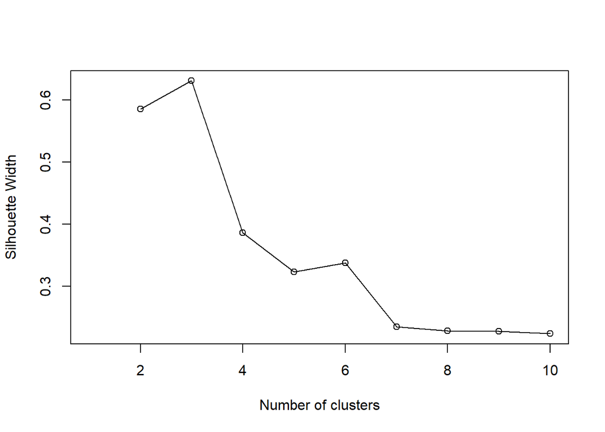

```r
# calculate silhouette width for many k using PAM
sil_width <- c(NA)

for (i in 2:10) {
  pam_fit <- pam(gower_dist,
                 diss = TRUE,
                 k = i)
  sil_width[i] <- pam_fit$silinfo$avg.width
}

# plot sihouette width (higher is better)
plot(1:10, sil_width,
     xlab = "Number of clusters",
     ylab = "Silhouette Width")
lines(1:10, sil_width)
```

# Cluster Interpretation

## Via Descriptive Statistics

After running the algorithm and selecting three clusters, we can interpret the clusters by running summary on each cluster.

```r
pam_fit <- pam(gower_dist, diss = TRUE, k = 3)

pam_results <- college_clean %>%
  dplyr::select(-name) %>%
  mutate(cluster = pam_fit$clustering) %>%
  group_by(cluster) %>%
  do(the_summary = summary(.))

pam_results$the_summary
```

```
## [[1]]
##   accept_rate        Outstate         Enroll         Grad.Rate
##  Min.   :0.3283   Min.   : 2340   Min.   :  35.0   Min.   : 15.00
##  1st Qu.:0.7225   1st Qu.: 8842   1st Qu.: 194.8   1st Qu.: 56.00
##  Median :0.8004   Median :10905   Median : 308.0   Median : 67.50
##  Mean   :0.7820   Mean   :11200   Mean   : 418.6   Mean   : 66.97
##  3rd Qu.:0.8581   3rd Qu.:13240   3rd Qu.: 484.8   3rd Qu.: 78.25
##  Max.   :1.0000   Max.   :21700   Max.   :4615.0   Max.   :118.00
##  Private        isElite       cluster
##  No :  0   Not Elite:500   Min.   :1
##  Yes:500   Elite    :  0   1st Qu.:1
##                            Median :1
##                            Mean   :1
##                            3rd Qu.:1
##                            Max.   :1
##
## [[2]]
##   accept_rate        Outstate         Enroll         Grad.Rate
##  Min.   :0.1545   Min.   : 5224   Min.   : 137.0   Min.   : 54.00
##  1st Qu.:0.4135   1st Qu.:13850   1st Qu.: 391.0   1st Qu.: 77.00
##  Median :0.5329   Median :17238   Median : 601.0   Median : 89.00
##  Mean   :0.5392   Mean   :16225   Mean   : 882.5   Mean   : 84.78
##  3rd Qu.:0.6988   3rd Qu.:18590   3rd Qu.:1191.0   3rd Qu.: 94.00
##  Max.   :0.9605   Max.   :20100   Max.   :4893.0   Max.   :100.00
##  Private       isElite      cluster
##  No : 4   Not Elite: 0   Min.   :2
##  Yes:65   Elite    :69   1st Qu.:2
##                          Median :2
##                          Mean   :2
##                          3rd Qu.:2
##                          Max.   :2
##
## [[3]]
##   accept_rate        Outstate         Enroll       Grad.Rate
##  Min.   :0.3746   Min.   : 2580   Min.   : 153   Min.   : 10.00
##  1st Qu.:0.6423   1st Qu.: 5295   1st Qu.: 694   1st Qu.: 46.00
##  Median :0.7458   Median : 6598   Median :1302   Median : 54.50
##  Mean   :0.7315   Mean   : 6698   Mean   :1615   Mean   : 55.42
##  3rd Qu.:0.8368   3rd Qu.: 7748   3rd Qu.:2184   3rd Qu.: 65.00
##  Max.   :1.0000   Max.   :15516   Max.   :6392   Max.   :100.00
##  Private        isElite       cluster
##  No :208   Not Elite:199   Min.   :3
##  Yes:  0   Elite    :  9   1st Qu.:3
##                            Median :3
##                            Mean   :3
##                            3rd Qu.:3
##                            Max.   :3
```

Based on these results:

1. It seems as though Cluster 1 is mainly Private/Not Elite with medium levels of out of state tuition and smaller levels of enrollment.
2. Cluster 2, on the other hand, is mainly Private/Elite with lower levels of acceptance rates, high levels of out of state tuition, and high graduation rates.
3. Cluster 3 is mainly Public/Not Elite with the lowest levels of tuition, largest levels of enrollment, and lowest graduation rate.